# lab4

#step1 read in the data

```r
library(data.table)
library(tidyverse)
#cache=true store the content and make running faster
if (!file.exists("met_all.gz"))
  download.file(
    url = "https://raw.githubusercontent.com/USCbiostats/data-science-data/master/02_met/met_all.gz",
    destfile = "met_all.gz",
    method   = "libcurl",
    timeout  = 60
    )
met <- data.table::fread("met_all.gz")
```

#step2 prepare the data ##nickname of r chunk

```r
met <- met[temp>=-17]
```

```r
met[, table(is.na(temp))]
```

```
##
##   FALSE
## 2317212
```

```r
met[, table(is.na(rh))]
```

```
##
##   FALSE    TRUE
## 2310917    6295
```

```r
met[, table(is.na(wind.sp))]
```

```
##
##   FALSE    TRUE
## 2285469   31743
```

```r
met[, table(is.na(vis.dist))]
```

```
##
##   FALSE    TRUE
## 2283538   33674
```

```r
met[, table(is.na(dew.point))]
```

```
##
##   FALSE    TRUE
## 2310917    6295
```

```r
met[, table(is.na(lat))]
```

```
##
##   FALSE
## 2317212
```

```r
met[, table(is.na(lon))]
```

```
##
##   FALSE
## 2317212
```

```r
met[, table(is.na(elev))]
```

```
##
##   FALSE
## 2317212
```

```r
met[, range(temp)]
```

```
## [1] -17  56
```

```r
met[, range(rh, na.rm = TRUE)]
```

```
## [1]   0.8334298 100.0000000
```

```r
met[, range(wind.sp, na.rm = TRUE)]
```

```
## [1]  0 36
```

```r
met[, range(vis.dist, na.rm = TRUE)]
```

```
## [1]      0 160000
```

```r
met[, range(dew.point, na.rm = TRUE)]
```

```
## [1] -37.2  36.0
```

```r
met[, range(lat, na.rm = TRUE)]
```

```
## [1] 24.550 48.941
```

```r
met[, range(lon, na.rm = TRUE)]
```

```
## [1] -124.290  -68.313
```

```r
met[, range(elev, na.rm = TRUE)]
```

```
## [1]  -13 9999
```

```r
met[elev ==9999.0, elev := NA]

met[, ymd :=as.Date(paste(year, month, day, sep = "-"))]

met[, table(week(ymd))]
```

```
##
##     31     32     33     34     35
## 297260 521605 527924 523847 446576
```

```r
met <- met[week(ymd) ==31]
```

#Compute the mean by station of the variables temp, rh, wind.sp, vis.dist, dew.point, lat, lon, and elev

```r
met_avg <- met[, .(
 temp = mean(temp, na.rm = TRUE),
 rh = mean(rh, na.rm = TRUE),
 wind.sp = mean(wind.sp, na.rm = TRUE),
 vis.dist = mean(vis.dist, na.rm = TRUE),
 dew.point = mean(dew.point, na.rm = TRUE),
 lat = mean(lat, na.rm = TRUE),
 lon = mean(lon, na.rm = TRUE),
 elev = mean(elev, na.rm = TRUE), USAFID
 ), by = "USAFID"]
```

#Create a region variable for NW, SW, NE, SE based on lon = -98.00 and lat = 39.71 degrees

```r
met_avg[lat >= 39.71 & lon <= -98, region := "Northwest"]
met_avg[lat < 39.71 & lon <= -98, region := "Southwest"]
met_avg[lat >=39.71 & lon > -98, region := "Northeast"]
met_avg[lat <39.71 & lon > -98, region := "Southeast"]

met_avg[, region2 := fifelse(lat >= 39.71 & lon <= -98, "Northwest",
        fifelse(lat < 39.71 & lon <= -98, "Southwest",
               fifelse(lat >=39.71 & lon > -98, "Northwest",
                       fifelse(lat < 39.71 & lon > -98, "Southwest", NA_character_))))]

met_avg[, table(region, region2, useNA = "always")]
```

```
##            region2
## region      Northwest Southwest <NA>
##   Northeast       484         0    0
##   Northwest       146         0    0
##   Southeast         0       649    0
##   Southwest         0       297    0
##   <NA>              0         0    0
```

#another way: met_avg[, region2 := fifelse(lat >= 39.71 & lon <=-98)]

#Create a categorical variable for elevation as in the lecture slides

```r
met_avg[, ele_cat := fifelse(elev >252, "high", "low")]

#deleting extra column
met_avg <- met_avg[, -1]
```

```r
library(tidyverse)
```

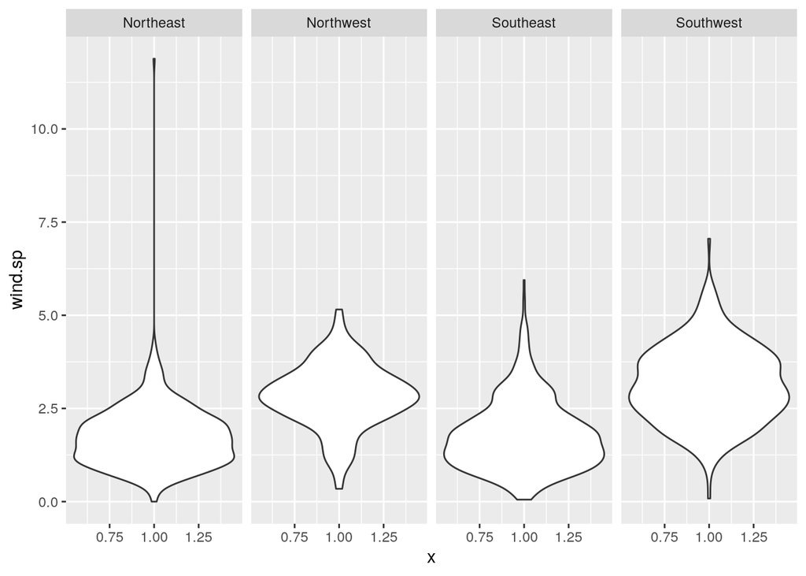

```r
#may need to delete using met_avg <- met_avg[, -c(?)]
ggplot(met_avg, mapping = aes(y = wind.sp, x=1))+
  geom_violin() +
  facet_grid(~region)
```

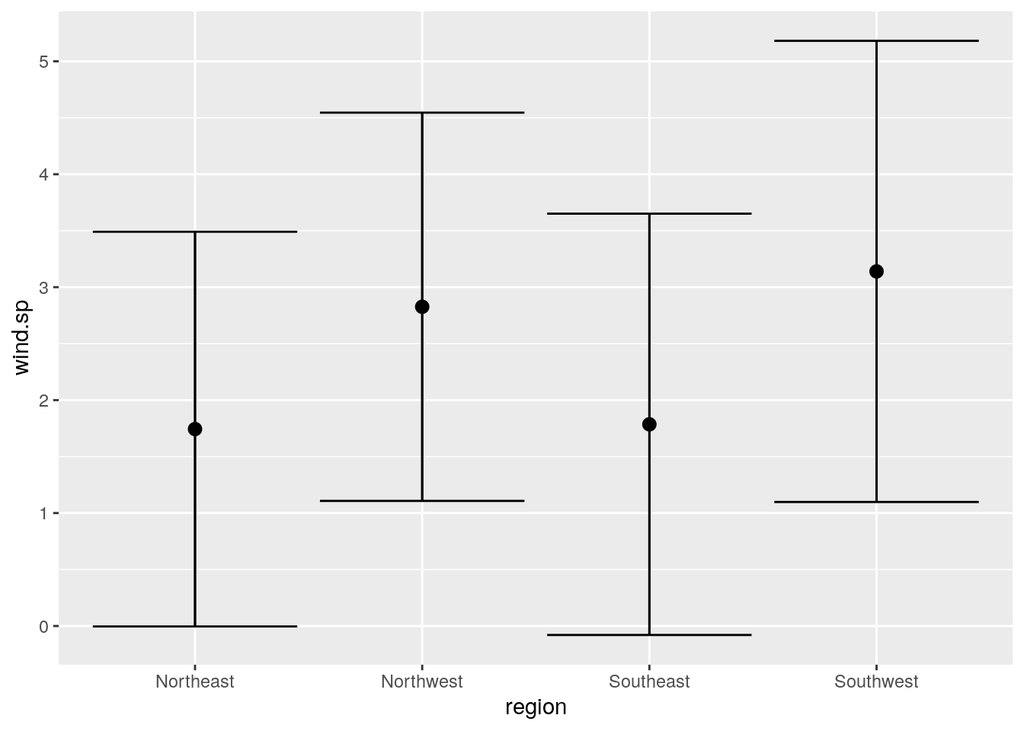

```r
ggplot(
  met_avg[!is.na(wind.sp) & !is.na(dew.point)],
  mapping = aes(x = region, y = wind.sp)) +
  stat_summary(fun.data = "mean_sdl") +
  stat_summary(fun.data = "mean_sdl", geom = "errorbar")
```

#step7 Make a map showing the spatial trend in relative h in the US

```r
library(leaflet)

temp.pal <- colorNumeric(c('darkgreen','goldenrod','brown'), domain=met_avg$rh)
leaflet(met_avg) %>%
  addProviderTiles('CartoDB.Positron') %>%
  addCircles(
    lat = ~lat, lng=~lon,
                                                  # HERE IS OUR PAL!
    label = ~paste0(round(rh,2), ' rh'), color = ~ temp.pal(rh),
    opacity = 1, fillOpacity = 1, radius = 500
    ) %>%
  # And a pretty legend
  addLegend('bottomleft', pal=temp.pal, values=met_avg$rh,
          title='Temperature, C', opacity=1)
```

[interactive chart not shown]